# HW8_Jie He

# g

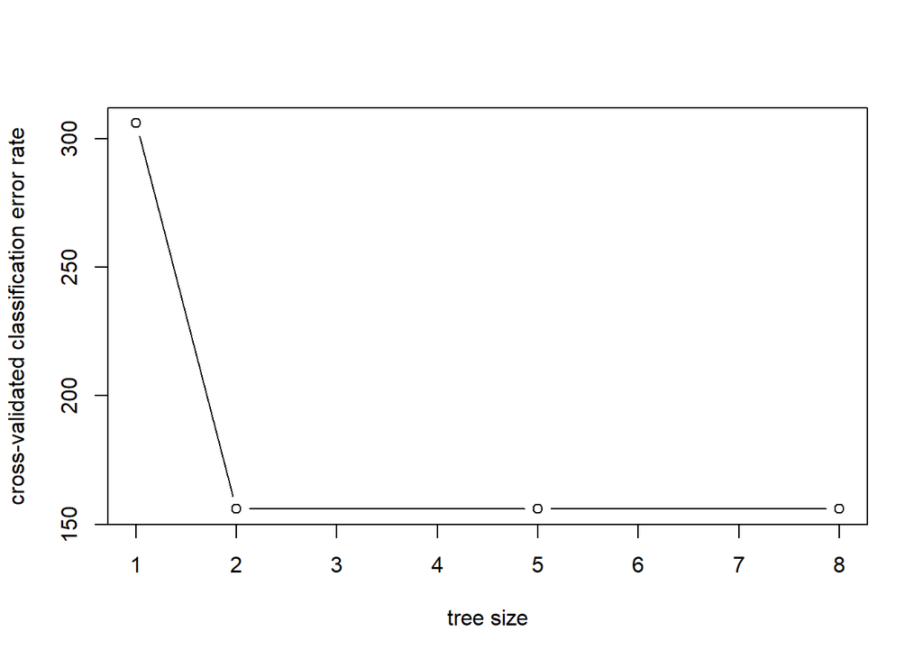

```r
plot(cv.obj$size, cv.obj$dev, type = "b", xlab = "tree size", ylab = "cross-validated classification error rate")
```

# h

The tree size equal to 2, 5 and 8 correspond to the lowest cross-validated classification error rate and 2 is the smallest size of the tree with the lowest cross-validated classification error rate.

# i

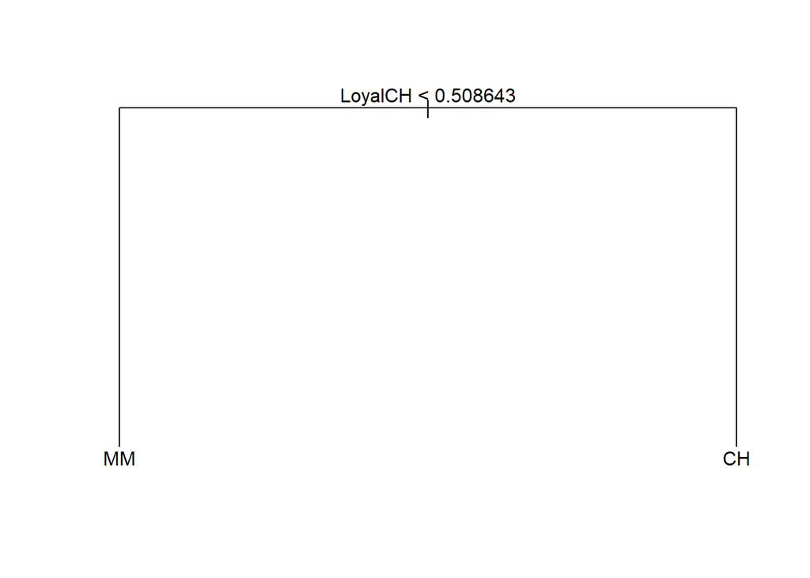

```r
prune_obj <- prune.misclass(treefit, best = 2)
plot(prune_obj)
text(prune_obj, pretty = 0)
```

# j

```r
summary(treefit)
```

```
##
## Classification tree:
## tree(formula = Purchase ~ ., data = train)
## Variables actually used in tree construction:
## [1] "LoyalCH"       "PriceDiff"     "SpecialCH"     "ListPriceDiff"
## Number of terminal nodes:  8
## Residual mean deviance:  0.7305 = 578.6 / 792
## Misclassification error rate: 0.165 = 132 / 800
```

```r
summary(prune_obj)
```

```
##
## Classification tree:
## snip.tree(tree = treefit, nodes = c(3L, 2L))
## Variables actually used in tree construction:
## [1] "LoyalCH"
## Number of terminal nodes:  2
## Residual mean deviance:  0.9115 = 727.4 / 798
## Misclassification error rate: 0.1825 = 146 / 800
```

The training error rates for pruned and unpruned trees are 0.1825 and 0.165. So the pruned one has a higher training error rate.

# k

```r
prunepred <- predict(prune_obj, test, type = "class")
table(prunepred, test$Purchase)
```

```
##
## prunepred  CH  MM
##        CH 119  30
##        MM  40  81
```

```r
(40+30)/(119+81+30+40)
```

```
## [1] 0.2592593
```

The test error rates for pruned and unpruned trees are 0.2592593 and 0.2259259. So the pruned one has a higher test error rate.

# Q12

```r
#with the MNIST_6-8 data

#load data set and transform the training data into a df
load("mnist_all.RData")
#data splitting
traindf <- data.frame(train)
training <- sample(1:nrow(traindf), 0.7*nrow(traindf))
trained <- traindf[training, ]
tested <- traindf[-training, ]
mydf <- trained
mytestdf <- tested

#remove rows other than 6 and 8
myData <- mydf[mydf$y == 6 | mydf$y == 8,]
myData_1 <- mytestdf[mytestdf$y == 6 | mytestdf$y == 8,]
```

```r
#pick a few dozen features
myfeatures_col_1 = c(408,436,380,464,463,353,352,381,491,435,
                     404,405,438,439,382,384,466,468,355,356,383,385,493,494,
                     276,277,256,258,232,233,291,292,166,168,170,171)

myDF <- myData[,c(myfeatures_col_1,786)]
myDF$labels = as.numeric(myData$y==6)
#myDF$labels

myDF_1 <- myData_1[,c(myfeatures_col_1,786)]
myDF_1$labels = as.numeric(myData_1$y==6)
#myDF_1$labels
```

```r
#logistic regression model
fit.lm_2 <- glm(labels ~ myDF[,1] + myDF[,2] + myDF[,3] + myDF[,4] + myDF[,5] + myDF[,6] + myDF[,7] + myDF[,8] + myDF[,9] + myDF[,10] + myDF[,11] + myDF[,12] + myDF[,13] + myDF[,14] + myDF[,15] + myDF[,16] + myDF[,17] + myDF[,18] + myDF[,19] + myDF[,20] + myDF[,21] + myDF[,22] + myDF[,23] + myDF[,24] + myDF[,25] + myDF[,26] + myDF[,27] + myDF[,28] + myDF[,29] + myDF[,30] + myDF[,31] + myDF[,32] + myDF[,33] + myDF[,34] + myDF[,35] + myDF[,36], data = myDF, family = binomial)
summary(fit.lm_2)
```

```
##
## Call:
## glm(formula = labels ~ myDF[, 1] + myDF[, 2] + myDF[, 3] + myDF[,
##     4] + myDF[, 5] + myDF[, 6] + myDF[, 7] + myDF[, 8] + myDF[,
##     9] + myDF[, 10] + myDF[, 11] + myDF[, 12] + myDF[, 13] +
##     myDF[, 14] + myDF[, 15] + myDF[, 16] + myDF[, 17] + myDF[,
##     18] + myDF[, 19] + myDF[, 20] + myDF[, 21] + myDF[, 22] +
##     myDF[, 23] + myDF[, 24] + myDF[, 25] + myDF[, 26] + myDF[,
##     27] + myDF[, 28] + myDF[, 29] + myDF[, 30] + myDF[, 31] +
##     myDF[, 32] + myDF[, 33] + myDF[, 34] + myDF[, 35] + myDF[,
##     36], family = binomial, data = myDF)
##
## Deviance Residuals:
##     Min       1Q   Median       3Q      Max
## -3.4922  -0.4726   0.0381   0.4796   3.8774
##
## Coefficients: (3 not defined because of singularities)
##               Estimate Std. Error z value Pr(>|z|)
## (Intercept)  3.3984285  0.1344156  25.283  < 2e-16 ***
## myDF[, 1]   -0.0030850  0.0007163  -4.307 1.66e-05 ***
## myDF[, 2]   -0.0006210  0.0007462  -0.832 0.405290
## myDF[, 3]   -0.0027296  0.0007581  -3.600 0.000318 ***
## myDF[, 4]   -0.0025793  0.0007040  -3.664 0.000249 ***
## myDF[, 5]   -0.0017685  0.0007712  -2.293 0.021843 *
## myDF[, 6]   -0.0032459  0.0006599  -4.919 8.69e-07 ***
## myDF[, 7]   -0.0038373  0.0005996  -6.400 1.55e-10 ***
## myDF[, 8]    0.0023204  0.0008988   2.582 0.009830 **
## myDF[, 9]    0.0024698  0.0005517   4.477 7.58e-06 ***
## myDF[, 10]  -0.0033460  0.0006478  -5.165 2.40e-07 ***
## myDF[, 11]   0.0080954  0.0004463  18.139  < 2e-16 ***
## myDF[, 12]  -0.0068123  0.0004490 -15.172  < 2e-16 ***
## myDF[, 13]  -0.0011302  0.0006438  -1.755 0.079198 .
## myDF[, 14]  -0.0026227  0.0006348  -4.132 3.60e-05 ***
## myDF[, 15]  -0.0037985  0.0009422  -4.031 5.54e-05 ***
## myDF[, 16]  -0.0052862  0.0009299  -5.685 1.31e-08 ***
## myDF[, 17]  -0.0050126  0.0006531  -7.675 1.65e-14 ***
## myDF[, 18]   0.0086606  0.0004914  17.624  < 2e-16 ***
## myDF[, 19]  -0.0018286  0.0007008  -2.609 0.009068 **
## myDF[, 20]  -0.0017873  0.0006687  -2.673 0.007524 **
## myDF[, 21]   0.0029768  0.0009445   3.152 0.001623 **
```

[output cut: 10 more lines]

```
## myDF[, 32]  -0.0033489  0.0004134  -8.101 5.46e-16 ***
## myDF[, 33]  -0.0013710  0.0021185  -0.647 0.517532
## myDF[, 34]  -0.0011582  0.0237509  -0.049 0.961107
## myDF[, 35]          NA         NA      NA       NA
## myDF[, 36]          NA         NA      NA       NA
## ---
## Signif. codes:  0 '***' 0.001 '**' 0.01 '*' 0.05 '.' 0.1 ' ' 1
##
## (Dispersion parameter for binomial family taken to be 1)
##
##     Null deviance: 11435.5  on 8248  degrees of freedom
## Residual deviance:  5590.5  on 8215  degrees of freedom
## AIC: 5658.5
##
## Number of Fisher Scoring iterations: 7
```

```r
fit.lm_2.predict <- predict(fit.lm_2, newdata = myDF_1, type = "response")
mean((fit.lm_2.predict-myDF_1$labels)^2)
```

```
## [1] 0.3905821
```

```r
#using random forest
library(randomForest)
set.seed(1)
fit.rf <- randomForest(labels ~ myDF[,1] + myDF[,2] + myDF[,3] + myDF[,4] + myDF[,5] + myDF[,6] + myDF[,7] + myDF[,8] + myDF[,9] + myDF[,10] + myDF[,11] + myDF[,12] + myDF[,13] + myDF[,14] + myDF[,15] + myDF[,16] + myDF[,17] + myDF[,18] + myDF[,19] + myDF[,20] + myDF[,21] + myDF[,22] + myDF[,23] + myDF[,24] + myDF[,25] + myDF[,26] + myDF[,27] + myDF[,28] + myDF[,29] + myDF[,30] + myDF[,31] + myDF[,32] + myDF[,33] + myDF[,34] + myDF[,35] + myDF[,36], data = myDF, mtry = 6)
fit.rf
```

```
##
## Call:
##  randomForest(formula = labels ~ myDF[, 1] + myDF[, 2] + myDF[,      3] + myDF[, 4] + myDF[, 5] + myDF[, 6] + myDF[, 7] + myDF[,      8] + myDF[, 9] + myDF[, 10] + myDF[, 11] + myDF[, 12] + myDF[,      13] + myDF[, 14] + myDF[, 15] + myDF[, 16] + myDF[, 17] +      myDF[, 18] + myDF[, 19] + myDF[,…
##                Type of random forest: regression
##                      Number of trees: 500
## No. of variables tried at each split: 6
##
##           Mean of squared residuals: 0.04892367
##                     % Var explained: 80.43
```

```r
fit.rf.predict <- predict(fit.rf, newdata = myDF)
mean((fit.rf.predict-myDF_1$labels)^2)
```

```
## [1] 0.4414661
```

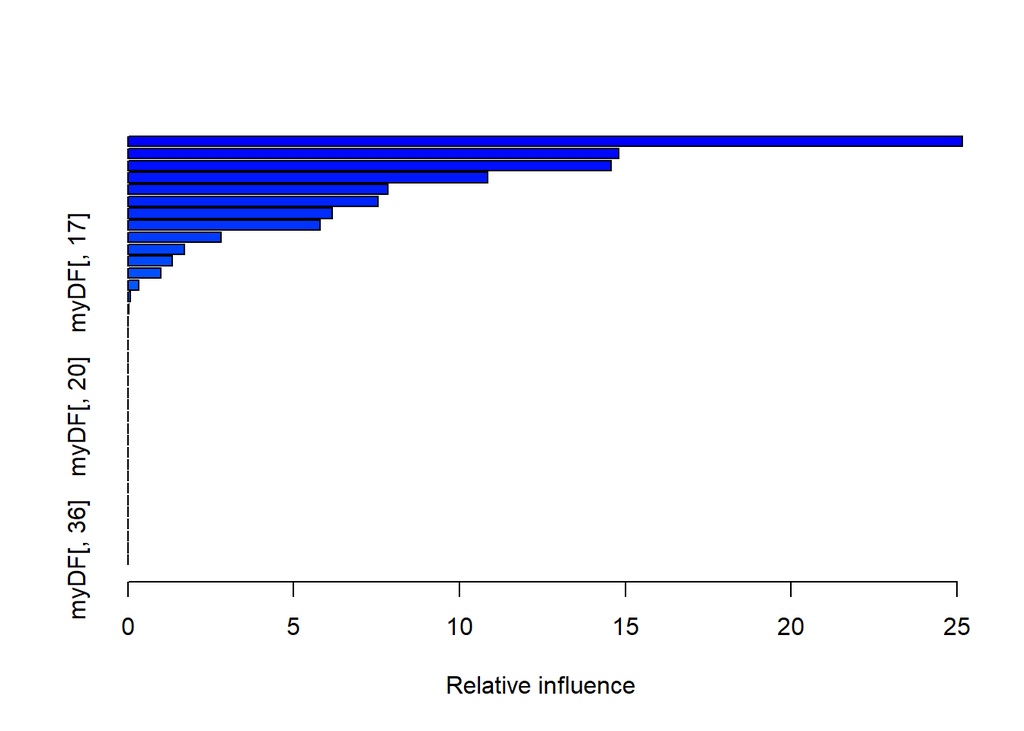

```
##                   var     rel.inf
## myDF[, 25] myDF[, 25] 25.16158101
## myDF[, 3]   myDF[, 3] 14.79239957
## myDF[, 10] myDF[, 10] 14.57575184
## myDF[, 11] myDF[, 11] 10.85309271
## myDF[, 22] myDF[, 22]  7.83341962
## myDF[, 1]   myDF[, 1]  7.55007135
## myDF[, 19] myDF[, 19]  6.16757031
## myDF[, 18] myDF[, 18]  5.79790426
## myDF[, 7]   myDF[, 7]  2.79461559
## myDF[, 2]   myDF[, 2]  1.71334439
## myDF[, 6]   myDF[, 6]  1.34360083
## myDF[, 17] myDF[, 17]  0.98328862
## myDF[, 4]   myDF[, 4]  0.33302809
## myDF[, 26] myDF[, 26]  0.06353837
## myDF[, 30] myDF[, 30]  0.03679344
## myDF[, 5]   myDF[, 5]  0.00000000
## myDF[, 8]   myDF[, 8]  0.00000000
## myDF[, 9]   myDF[, 9]  0.00000000
## myDF[, 12] myDF[, 12]  0.00000000
## myDF[, 13] myDF[, 13]  0.00000000
## myDF[, 14] myDF[, 14]  0.00000000
## myDF[, 15] myDF[, 15]  0.00000000
## myDF[, 16] myDF[, 16]  0.00000000
## myDF[, 20] myDF[, 20]  0.00000000
## myDF[, 21] myDF[, 21]  0.00000000
## myDF[, 23] myDF[, 23]  0.00000000
## myDF[, 24] myDF[, 24]  0.00000000
## myDF[, 27] myDF[, 27]  0.00000000
## myDF[, 28] myDF[, 28]  0.00000000
## myDF[, 29] myDF[, 29]  0.00000000
## myDF[, 31] myDF[, 31]  0.00000000
## myDF[, 32] myDF[, 32]  0.00000000
## myDF[, 33] myDF[, 33]  0.00000000
## myDF[, 34] myDF[, 34]  0.00000000
## myDF[, 35] myDF[, 35]  0.00000000
## myDF[, 36] myDF[, 36]  0.00000000
```

```r
#using boosting
library(gbm)
set.seed(1)
fit.boost <- gbm(labels ~ myDF[,1] + myDF[,2] + myDF[,3] + myDF[,4] + myDF[,5] + myDF[,6] + myDF[,7] + myDF[,8] + myDF[,9] + myDF[,10] + myDF[,11] + myDF[,12] + myDF[,13] + myDF[,14] + myDF[,15] + myDF[,16] + myDF[,17] + myDF[,18] + myDF[,19] + myDF[,20] + myDF[,21] + myDF[,22] + myDF[,23] + myDF[,24] + myDF[,25] + myDF[,26] + myDF[,27] + myDF[,28] + myDF[,29] + myDF[,30] + myDF[,31] + myDF[,32] + myDF[,33] + myDF[,34] + myDF[,35] + myDF[,36], data = myDF, distribution = "gaussian", n.trees = 5000)
summary(fit.boost)
```

```r
fit.boost.predict <- predict(fit.boost, newdata = myDF_1, n.trees = 5000)
mean((fit.boost.predict-myDF_1$labels)^2)
```

```
## [1] 0.3117986
```

From the above, we can see that boosting gave the lowest test MSE and logistic regression is not the worst method.